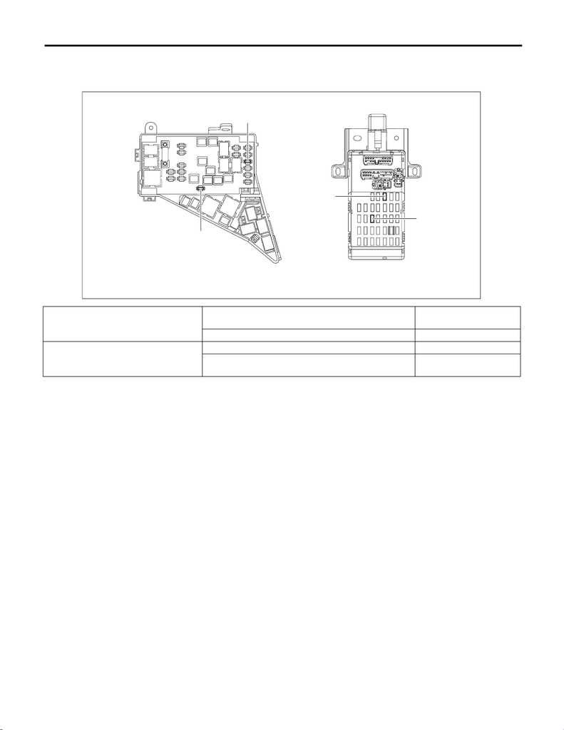

SL-8

Relay and Fuse

SECURITY AND LOCKS

2. Relay and Fuse

A: LOCATION

NOTE:

For other related fuses, refer to the wiring diagram. <Ref. to WI-28, Power Supply Circuit.>

B: INSPECTION

1. CHECK FUSE

1) Remove the fuse and inspect visually.

2) If the fuse is blown out, replace the fuse.

NOTE:

If the fuse is blown again, check the system wiring harness.

Main fuse box

Fuse 15A (turn signal & hazard module, body integrated

unit)

(A)

Fuse 20 A (body integrated unit, immobilizer antenna) (B)

Relay & fuse box

Fuse 15 A (body integrated unit) (C)

Fuse 10 A (keyless access CM, TPMS & keyless entry

CM)

(D)

SL-01470

(B)

(A)

(D)

(C)

M/B F/B

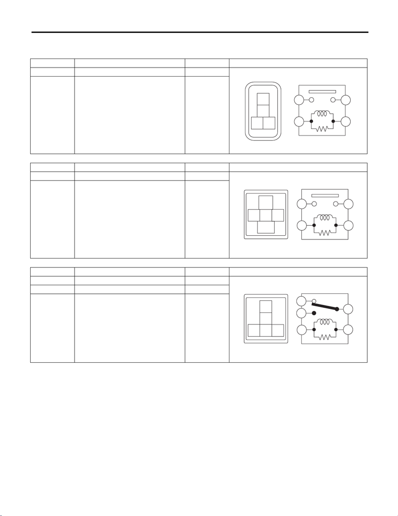

SL-9

Relay and Fuse

SECURITY AND LOCKS

2. CHECK RELAY

1) Measure the resistance between relay terminals.

2) Replace the relay if the inspection result is not within the standard value.

Terminal No. Inspection conditions Standard Circuit

1 — 2 Always 1 MΩ or more

1 — 2

Apply battery voltage between terminals

4 and 3.

Less than 1 Ω

Terminal No. Inspection conditions Standard Circuit

1 — 4 Always 1 MΩ or more

1 — 4

Apply battery voltage between terminals

2 and 3.

Less than 1 Ω

Terminal No. Inspection conditions Standard Circuit

1 — 2 Always 1 MΩ or more

1 — 4 Always Less than 1 Ω

1 — 2

Apply battery voltage between terminals

3 and 5.

Less than 1 Ω

LI-01273

1

2

34

2

3 4

1

AC-02796

1

2

3

4

4

2 3

1

SL-01566

2

4

3

5

1

1

2

34

5